## Put a plot on a plot next to a plot.

1. Schreiben Sie eine verbesserte & kommentierte Version `my_plot_scatterhist()` die
   - die in der Vorlesung besprochenen Prinzipien für saubere Programmkonzeption befolgt,
   - mit möglichst vielen Arten von Inputs die sich zu einer numerischen Matrix umwandeln lassen funktioniert,
   - alle in ihr geänderten Grafikparameter wieder auf ihre ursprünglichen Werte zurücksetzt,
   - auch für nicht gleich breite Histogrammzellen das richtige tut,
   - *nicht* die defaults von `hist()` für `breaks` mit eigenen defaults überschreibt, sondern per default die defaults von `hist()` für `breaks` benutzt.
   - Bonus: die anders als `plot_scatterhist()` wirklich korrekte Plots produziert. Stichwort: **exakte**(!) Übereinstimmung der Achsen für Histogramme und Scatterplots…

   Ihre Funktion sollte also z.B. für `my_plot_scatterhist(trees)` eine Warnung ausgeben dass nur die ersten beiden Spalten verwendet werden und dann genau das richtige tun, nicht nur so ungefähr wie z.B. `plot_scatterhist(cbind(trees[,1], trees[,2]), xbreaks=7, ybreaks=7)`.
2. Schreiben Sie eine sauber konzipierte & kommentierte Funktion `plot_scatterplus()` die statt Histogrammen optional auch Boxplots oder Kerndichteschätzer über die Achsen plotten kann. Wie sollten die Optionen für solche Boxplots/KDEs übergeben werden? Beispielplots die ihre Funktion für (die ersten beiden Spalten von) `trees` z.B. (so ähnlich) erzeugen können sollte:

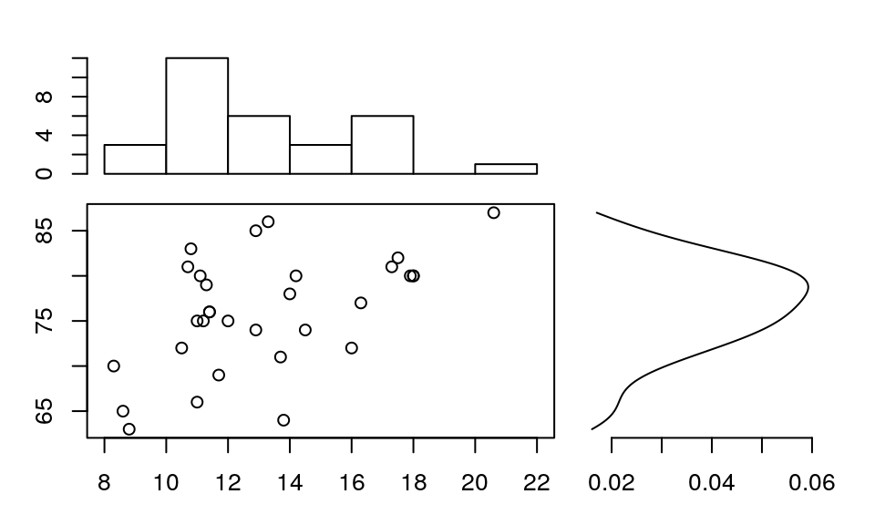

oder sowas:

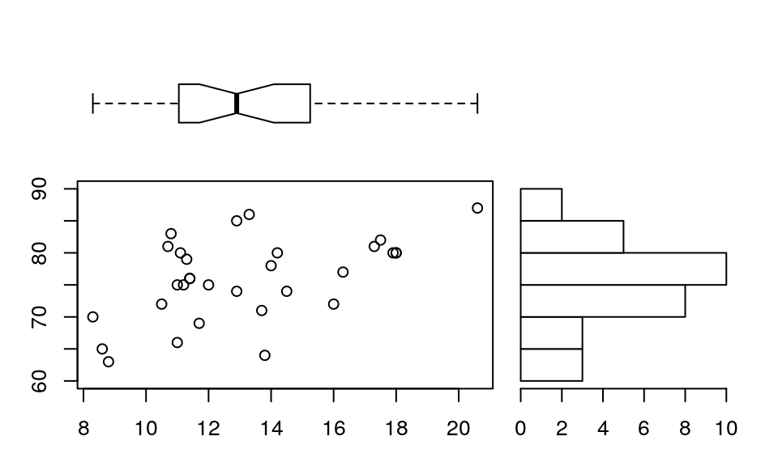

oder sowas:

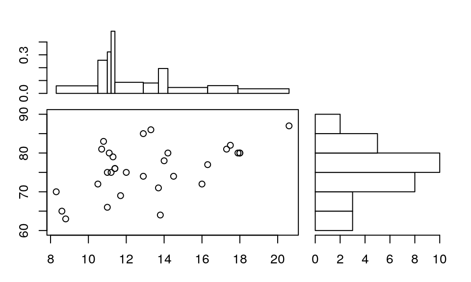